# Two Factor ANOVA Problem Set

Your Name Here

# 1 Introduction

This problem set corresponds to the section on two factor ANOVA in the course https://doe.dscoe.org.

For this problem set, we will use the following packages:

```r
library(tidyverse)
```

# 2 Weapon System

In this problem, you are an analyst developing requirements for a future soldier weapon. You have a physics simulation that incorporates the input data for both the weapon system and the range the system is employed at. It provides the number of targets hit as an output. The data is available as weapon_range.csv .

## 2.1 Read the Data

Read the data, format it as required, and identify the factors, levels, and numbers of replicates.

```r
# Read the data
wr <- read.csv('./weapon_range.csv')
# Ensuring you keep the range and weapon system as a factor vs. a number
# Enables more appropriate visualization
wr$Range <- as.factor(wr$Range)
wr$Weapon <- as.factor(wr$Weapon)

summary(wr)
```

```
##  Range    Weapon    Targets
##  50 :18   1:18   Min.   :23.00
##  150:18   2:18   1st Qu.:28.00
##  200:18   3:18   Median :34.00
##                  Mean   :31.94
##                  3rd Qu.:36.00
##                  Max.   :39.00
```

```r
# Factor A: Range with 3 levels
# Factor B: Weapon with 3 levels
# There are 6 replicates per treatment combination
```

## 2.2 Visualize the Data

Produce trace-plots of the mean number of targets engaged as a function of both the weapon and the range. What do you observe based on these?

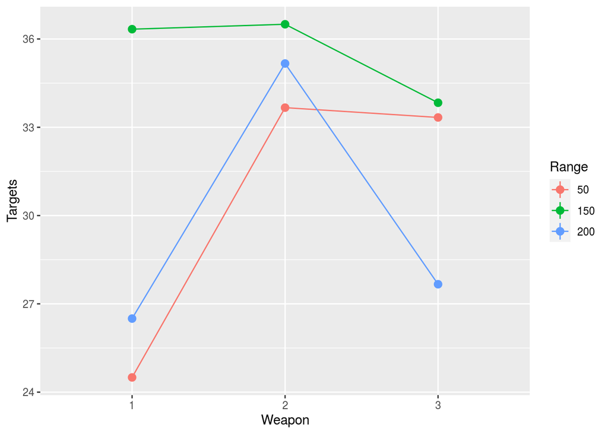

```r
# Produce a trace plot.  You can do this in a number of ways, on the example I
# powered through with formatting the data to get the means and then using geom_point and geom_segement
# but these stat summary functions are super useful

# This provides you with the x and y axis; you need the group aesthetic to appropriately
# do the grouping for the summary statistics
ggplot(data = wr, aes(x = Weapon, y = Targets, color = Range, group = Range)) +
  # Plot the means as points
  stat_summary(fun = 'mean') +
  # "Connect the dots
  stat_summary(fun = 'mean', geom = 'line')
```

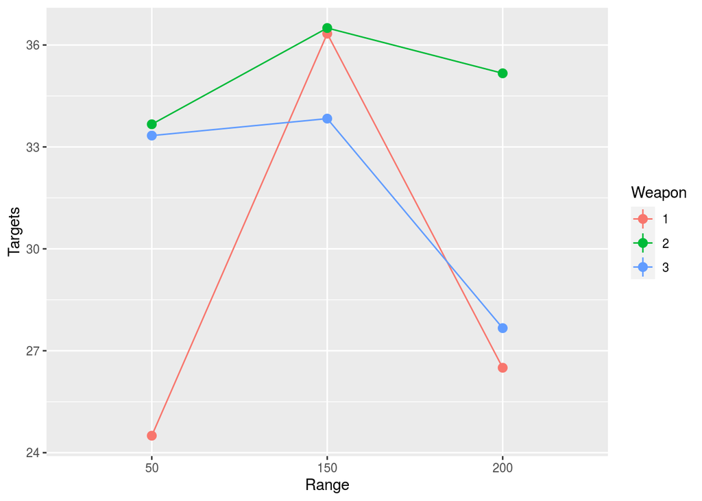

```r
# This is the same plot, but with
ggplot(data = wr, aes(x = Range, y = Targets, color = Weapon, group = Weapon)) +
  stat_summary(fun = 'mean') +
  stat_summary(fun = 'mean', geom = 'line')
```

```r
# We see rather clearly that there is an interaction effect between range and weapon system
```

## 2.3 Conduct the ANOVA

Conduct a two-factor ANOVA for this analysis, check your assumptions, and draw relevant conclusions.

```r
wr.aov <- aov(Targets ~ Range + Weapon + Range:Weapon, data = wr)
summary(wr.aov)
```

```
##              Df Sum Sq Mean Sq F value   Pr(>F)
## Range         2  356.8  178.39   29.79 5.76e-09 ***
## Weapon        2  327.0  163.50   27.30 1.72e-08 ***
## Range:Weapon  4  289.6   72.39   12.09 9.38e-07 ***
## Residuals    45  269.5    5.99
## ---
## Signif. codes:  0 '***' 0.001 '**' 0.01 '*' 0.05 '.' 0.1 ' ' 1
```

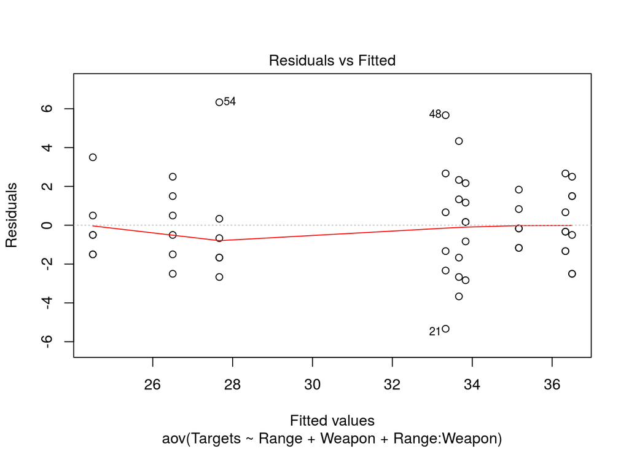

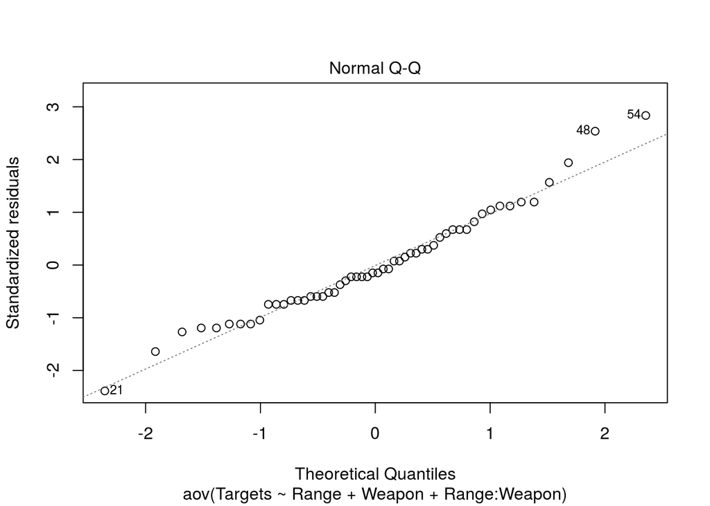

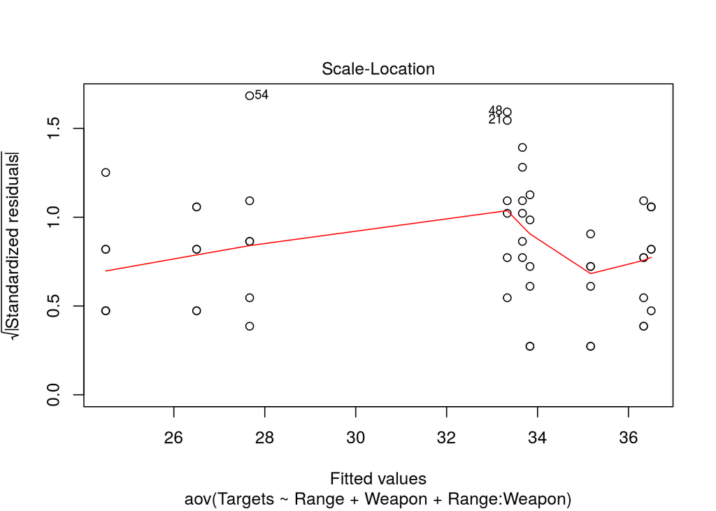

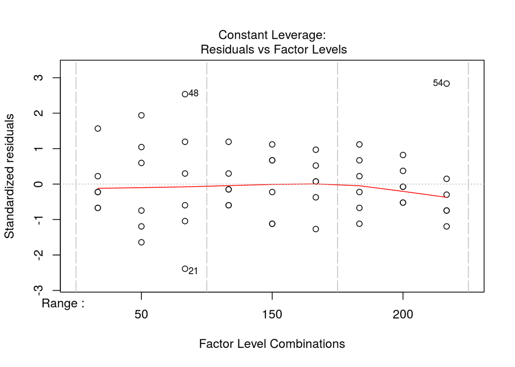

```r
# Clearly both factors and their interaction have an impact on the
# number of targets engaged.

plot(wr.aov)
```

```r
# It appears that we meet the assumptions of independent, normally distributed, and homoskedatic errors
# Let's check numerically:

# Normality
shapiro.test(wr.aov$residuals)
```

```
##
##  Shapiro-Wilk normality test
##
## data:  wr.aov$residuals
## W = 0.97353, p-value = 0.2745
```

```r
# We fail to reject the null that the residuals are normally distributed

# Homoskedasticity
bartlett.test(wr.aov$residuals, wr$Range)
```

```
##
##  Bartlett test of homogeneity of variances
##
## data:  wr.aov$residuals and wr$Range
## Bartlett's K-squared = 4.6239, df = 2, p-value = 0.09907
```

```r
bartlett.test(wr.aov$residuals, wr$Weapon)
```

```
##
##  Bartlett test of homogeneity of variances
##
## data:  wr.aov$residuals and wr$Weapon
## Bartlett's K-squared = 5.199, df = 2, p-value = 0.07431
```

```r
# These both pass the test at an alpha of .05.  Given the relatively small number of replicates,
# it's probably safe to assume constant variance
```

# 3 Tank Gunnery Problem

You are conducting a study assessing the utility of a sensor for a tank. There are three possible choices for the sensor: “Gen 1”, “Gen 2”, and “Gen 3”. You have a human in the loop simulation where users can virtually conduct a tank gunnery. As you know the abilities of gunners can vary greatly, you randomly select five gunners out of a tank battalion and name them “A”, “B”, “C”, “D”, “E” and have them conduct the gunnery in your simulation. You provide each gunner with a random order to conduct the simulations. Each gunner does each simulation four times. You measure their probability of hit in the simulation. Your data is contained in gunnery.csv .

## 3.1 Conceptual

What type of model is this?

```
This is a two factor, mixed-effects model
```

What are your factors and the levels?

```
Factor 1: The sensor with 3 x levels: Gen 1, Gen 2, Gen 3 (Fixed).
Factor 2: The gunner.  We had 5 randomly selected levels out of a larger population.
The interaction Factor 1 x Factor 2: There are 15 levels of the interaction.
```

## 3.2 Read and Format the Data

```r
# Read the csv and format as factors
gunnery <- read.csv('./gunnery.csv')
gunnery$Sensor <- as.factor(gunnery$Sensor)
gunnery$Gunner <- as.factor(gunnery$Gunner)
head(gunnery)
```

```
##   Sensor Gunner Percent.Kills
## 1  Gen 1      A         0.204
## 2  Gen 2      A         0.471
## 3  Gen 3      A         0.726
## 4  Gen 1      B         0.185
## 5  Gen 2      B         0.520
## 6  Gen 3      B         0.903
```

## 3.3 Visualize the Data with Trace Plots

Produce trace plots for each factor. Interpret your results.

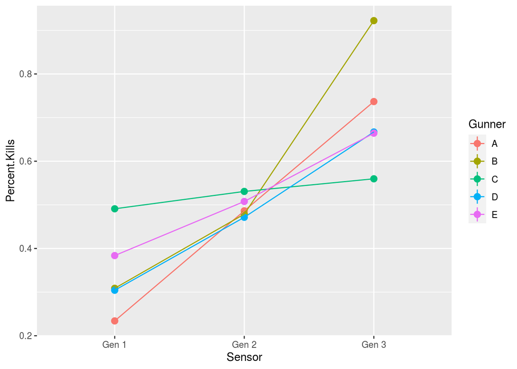

```r
ggplot(data = gunnery, aes(x = Sensor, y = Percent.Kills, color = Gunner, group = Gunner)) +
  stat_summary(fun = 'mean') +
  stat_summary(fun = 'mean', geom = 'line')
```

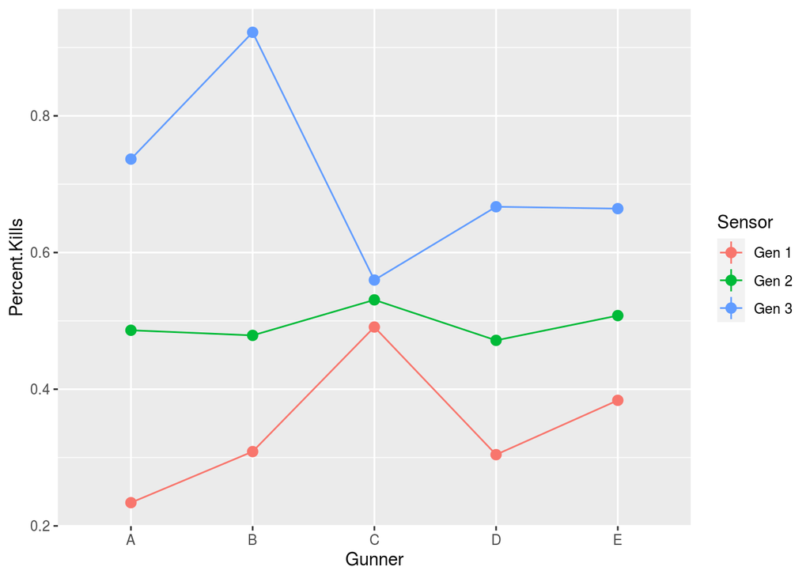

```r
# Based on this it looks as though the choice of sensor has a clear effect.
# It's hard to say if the actual gunner matters that much, except perhaps
# there is a significant interaction between gunner B and sensor 3 and
# between gunner C and sensor 1

ggplot(data = gunnery, aes(x = Gunner, y = Percent.Kills, color = Sensor, group = Sensor)) +
  stat_summary(fun = 'mean') +
  stat_summary(fun = 'mean', geom = 'line')
```

```r
# This plot mirrors the analysis seen in the other plots
```

## 3.4 ANOVA

Conduct the ANOVA, check your assumptions, and analyze your results.

```r
gunnery.aov <- aov(Percent.Kills ~ . + .:., data = gunnery)
summary(gunnery.aov)
```

```
##               Df Sum Sq Mean Sq F value   Pr(>F)
## Sensor         2 1.3508  0.6754  87.458 3.14e-16 ***
## Gunner         4 0.0623  0.0156   2.016    0.108
## Sensor:Gunner  8 0.3886  0.0486   6.291 1.87e-05 ***
## Residuals     45 0.3475  0.0077
## ---
## Signif. codes:  0 '***' 0.001 '**' 0.01 '*' 0.05 '.' 0.1 ' ' 1
```

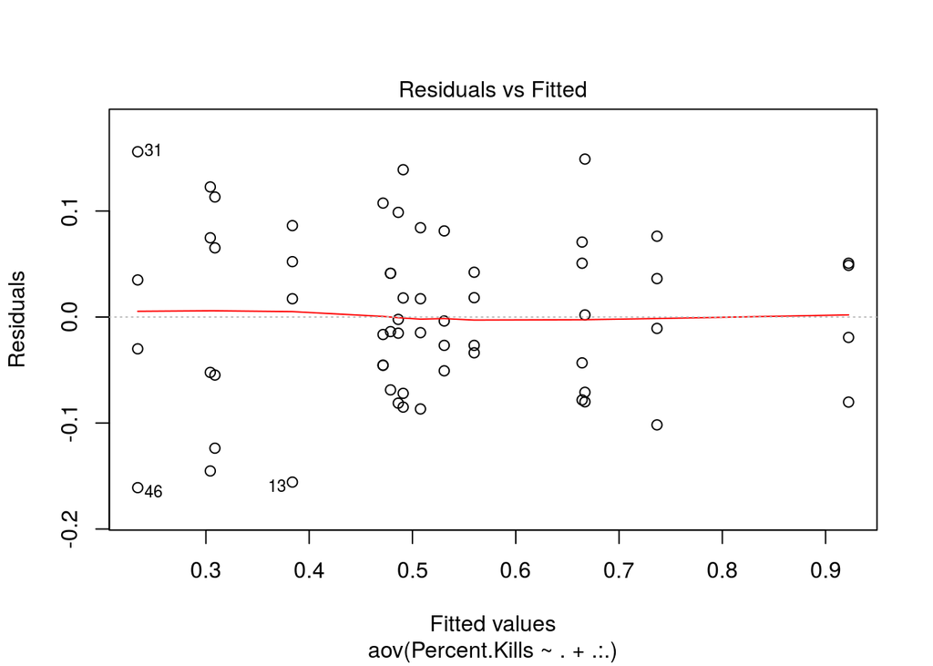

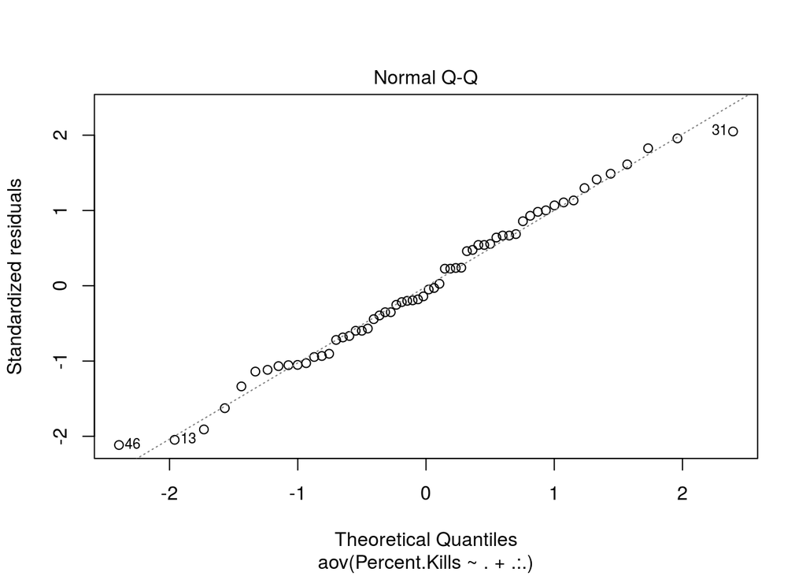

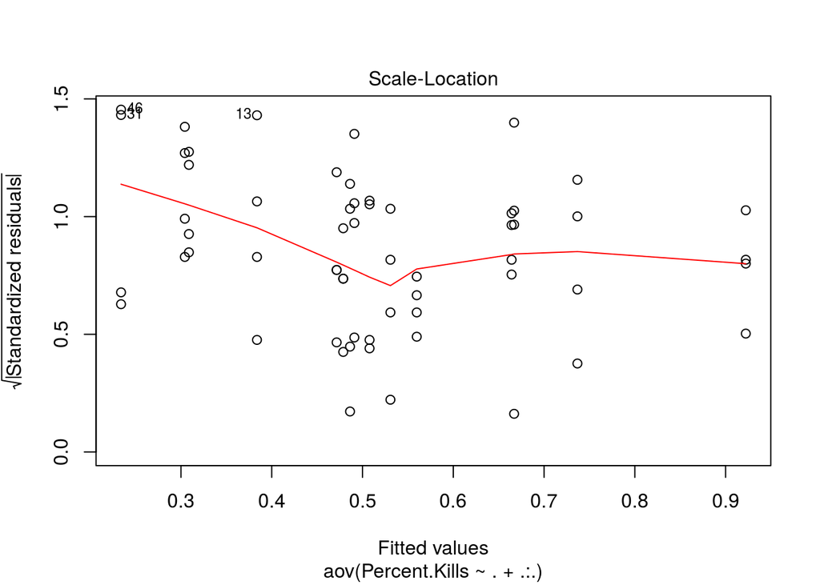

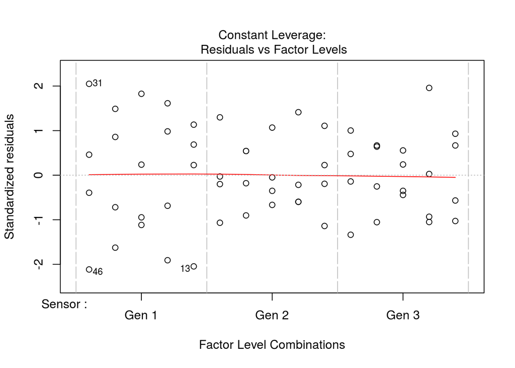

```r
# We see that both the sensor and interaction are signifcant at alpha = .05

plot(gunnery.aov)
```

```r
# The plots do not give us any indication that our data
# is not normally distributed, heteroskedatic, or dependent

# Normality
shapiro.test(gunnery.aov$residuals)
```

```
##
##  Shapiro-Wilk normality test
##
## data:  gunnery.aov$residuals
## W = 0.98571, p-value = 0.7068
```

```r
# Our residuals are normally distributed by a shaprio wilk test

# Homoskedasticity
bartlett.test(gunnery.aov$residuals, gunnery$Sensor)
```

```
##
##  Bartlett test of homogeneity of variances
##
## data:  gunnery.aov$residuals and gunnery$Sensor
## Bartlett's K-squared = 6.705, df = 2, p-value = 0.035
```

```r
bartlett.test(gunnery.aov$residuals, gunnery$Gunner)
```

```
##
##  Bartlett test of homogeneity of variances
##
## data:  gunnery.aov$residuals and gunnery$Gunner
## Bartlett's K-squared = 1.882, df = 4, p-value = 0.7574
```

```r
# We may have some deaprtures from heoskedasticity, but its not clear...
```